# MATH70076: Data Science - Formative Assessment

MSc in Statistics 2026/27, Imperial College London

Author

06082133

**Deadline: Monday 12 October 2026 at 13:00.**

*For this formative assessment you should submit two files via the Imperial College VLE on Canvas by the deadline stated above. Your files should be named as follows:*

- `YOURCID-MATH70076-formative-assessment.pdf`: your rendered report,
- `YOURCID-MATH70076-formative-assessment.zip`: a zip file containing the relevant source code to generate your report.

*All submitted materials should be clearly presented and be understandable as stand-alone documents.*

*Please note that large files can take quite some time to upload. Ensure that you upload each document to the correct part of the learning space in a timely manner.*

*This mock coursework is a formative assessment and so will not contribute to your overall grade for the module. It is designed for you to practice the skills you have learned in the first workshop and to get feedback on your reflective writing style. This activity is expected to take approximately 6 hours of individual effort. Assessment criteria are given in the “set yourself up for success” boxes. Satisfying 18 or more out of these 23 criteria corresponds to a notional “pass” grade.*

*In submitting this mock assessment you certify that it is entirely your own work, apart from where otherwise acknowledged, and includes no plagiarism. Note that software tools are used as part of plagiarism detection.*

## Background

### Generalised Pareto Distribution

The Generalized Pareto Distribution (GPD) is a flexible family of continuous probability distributions that arises naturally in extreme value theory, particularly for modelling the distribution of excesses over a threshold. It is parametrised by a shape parameter $\xi \in \mathbb{R}$, a scale parameter $\sigma > 0$, and a location parameter $u \in \mathbb{R}$. Its cumulative distribution function (CDF) is given by

$$F(x;\,\sigma,\xi, u) =
\begin{cases}
1 - \left(1 + \dfrac{\xi (x-u)}{\sigma}\right)_+^{-1/\xi}, & \xi \neq 0, \, x \geq u; \; \\[1.2em]
1 - \exp\!\left(-\dfrac{x-u}{\sigma}\right), & \xi = 0, \, x \geq u;
\end{cases}
\tag{1}$$

where $x_+ = \max(x,0)$ and its probability density function (PDF) is

$$f(x;\sigma,\xi,u) =
\begin{cases}
\dfrac{1}{\sigma}\left(1 + \dfrac{\xi (x-u)}{\sigma}\right)_+^{-1/\xi - 1}, & \xi \neq 0, \\[1.2em]
\dfrac{1}{\sigma}\exp\!\left(-\dfrac{x-u}{\sigma}\right), & \xi = 0,
\end{cases}
\tag{2}$$

defined on the same support as the CDF. The GPD encompasses a variety of tail behaviours:

- when $\xi > 0$ the GPD has heavy, slowly decaying tails,
- in limiting case when $\xi \rightarrow 0$ the GPD reduces to an exponential distribution;
- when $\xi < 0$ the GPD has light, quickly decaying tails with a finite upper endpoint of $x^+ = u - \sigma / \xi$.

### Probability Integral Transform

The probability integral transform states that if a random variable $X$ has a continuous cumulative distribution function $F_X(x)$, then the transformed variable $A = F_X(X)$ follows a uniform distribution on $[0,1]$. Conversely, if $F$ is an invertible function then $Y = F^{-1}_X(A)$ has the same distribution as $X$.

## Questions

### Question 1

Derive an expression for the inverse cumulative distribution function (also known as the quantile function) $F^{-1}_X: [0,1] \rightarrow [u, x^+]$ of $X \sim \text{GPD}(u, \sigma, \xi)$. Your answer should refer to at least one equation given in the background material.

**TipSet yourself up for success**

Does your answer contain:

- a few sentences of text describing your approach to the problem;
- a reference to at least one equation from the background section;
- a correctly formatted LaTeX equation;
- a valid approach to the problem and correct expression.

### Answer 1

For this question, I consider the two cases of the GPD separately, based on whether or not $\xi$ is equal to zero. In each case, I assign $y=F(x;\,\sigma, \xi, u)$ and solve for $x$.

Firstly, for $\xi \neq 0$:

When $\xi$ is positive, the support $x \geq u$ is sufficient to make the bracketed term positive, and when $\xi$ is negative, the support $u \leq x \leq u - \sigma / \xi$ is sufficient to make the bracketed term positive. In both cases, I can ignore the the subscript $+$ in Equation 1 and write:

$$y=F(x;\,\sigma, \xi, u) = 1 - \left(1 + \dfrac{\xi (x-u)}{\sigma}\right)^{-1/\xi}$$

The rearrangement continues:

$$1-y = \left(1 + \dfrac{\xi (x-u)}{\sigma}\right)^{-1/\xi}$$
$$\left(1-y\right)^{-\xi} = 1 + \dfrac{\xi (x-u)}{\sigma}$$
$$\xi (x-u) = \sigma [\left(1-y\right)^{-\xi} - 1]$$
$$x = u + \dfrac{\sigma}{\xi} \left[\left(1-y\right)^{-\xi} - 1\right]$$

Next, for the case $\xi = 0$, we have:

$$y = F(x;\,\sigma, 0, u) = 1 - \exp\!\left(-\dfrac{x-u}{\sigma}\right)$$

$$1-y = \exp\!\left(-\dfrac{x-u}{\sigma}\right)$$

$$x - u = -\sigma \log(1-y)$$

$$x = u - \sigma \log(1-y)$$

This gives the final expression for the inverse function:

$$F^{-1}_X(y;\,\sigma, \xi, u) =
\begin{cases}
u + \dfrac{\sigma}{\xi} \left[\left(1-y\right)^{-\xi} - 1\right], & \xi \neq 0, \\[1.2em]
u - \sigma \log(1-y), & \xi = 0.
\end{cases}$$

### Question 2

*For this question you should display the R code you use to define and document `qgpd()` within the main text of your report.*

1. Write and document your own function `qgpd()` to calculate quantiles of a given generalised Pareto distribution. Your function should have inputs and behaviour similar to the built-in R functions such as `qnorm()` and `qunif()` and check that inputs are in the correct format.
2. Suppose a random variable $X$ follows an generalised Pareto distribution with threshold parameter $u=1.5$, scale parameter $\sigma = 2$ and shape parameter $\xi = -0.4$. Use your function to find quantiles $x_p$ for $p = 0.5, 0.75, 0.99$ (i.e. for each $p$ find the value for which $\Pr(X < x_p) = p$).

**TipSet yourself up for success**

Does your answer:

- contain a valid R function definition;
- document the expected inputs, outputs and behaviours of that function;
- check the validity of inputs;
- handle any edge-cases in an appropriate way;
- return the correct quantile values?

### Answer 2

#### (a) R function code

```r
# ANSWER 2
# a)
qgpd <- function(p, u = 0, sigma = 1, xi = 0) {
# Assumes default values if none specified as in qnorm or qunif
# Inputs:
# p: A numeric vector of values in [0, 1]
# u: A location parameter in (-inf, inf)
# sigma: A scale parameter in (0, inf)
# xi: A shape parameter in (-inf, inf)

  for (i in c(p, u, sigma, xi)) {
    if (!is.numeric(i)) {
      stop("All inputs must be numeric.")
    }
  }
  if (any(p < 0 | p > 1)) {
      stop("All probabilities must be in the range [0, 1].")
  }
  if (sigma <= 0) {
    stop("Sigma must be positive.")
  }

  # Calculate quantiles based on the value of xi
  if (xi != 0) {
    return(u + (sigma / xi) * ((1 - p)^(-xi) - 1))
  } else {
    return(u - sigma * log(1 - p))
  }
}
```

#### (b) Calculations

The formula gives the quantiles as:

```r
# b)
qgpd(p = c(0.5, 0.75, 0.99), u = 1.5, sigma = 2, xi = -0.4)
```

```
[1] 2.710709 3.628254 5.707553
```

### Question 3

*For this question, all R code should be displayed only within the appendix, not in the main report.*

The file `gpd_samples.csv` contains six sets of random variates generated from different generalised Pareto distributions. The details of the generalised Pareto distributions used are summarised in `gpd_parameters.csv`. Unfortunately some of the parameter sets were recorded incorrectly.

Within a single figure, construct a series of quantile-quantile plots to identify which datasets are inconsistent with their stated distributions. You should both justify your conclusions and describe your level of confidence in your findings.

**TipSet yourself up for success**

Does your solution contain:

- at least one quantile-quantile plot;
- six qq-plots in a single figure;
- use of loops, vectorisation, or function definitions to avoid repetitive code.
- figures with clear text, useful captions and appropriate visual mapping of data;
- a few paragraphs describing and justifying your findings and referencing the figure;

### Answer 3

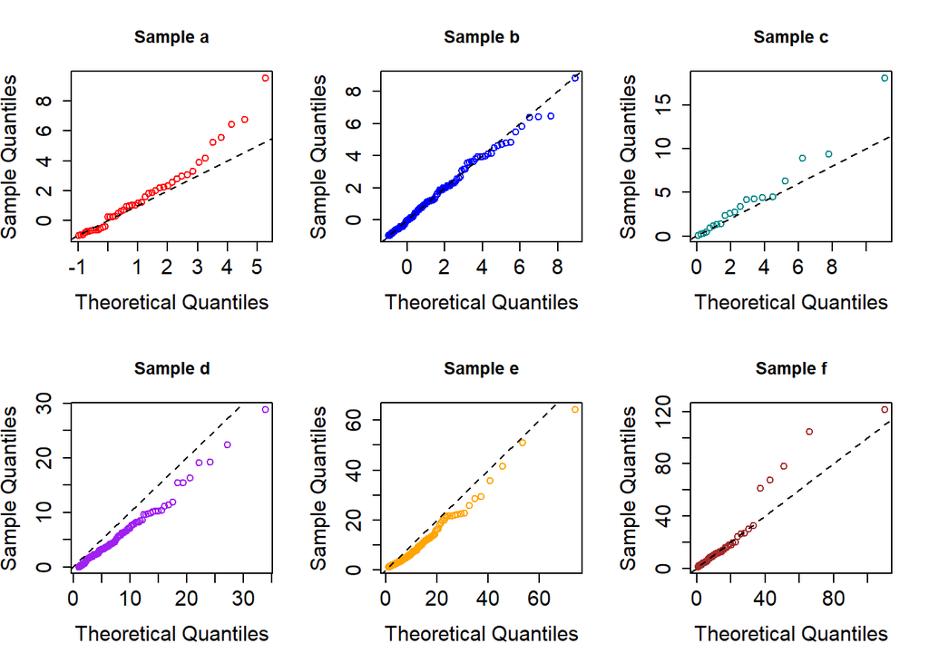

Figure 1: QQ plots generated by 6 different samples.

Whilst some of the graphs appear to definitively show whether or not the parameters are correct, the relatively low size of the samples and rudimentary nature of the readings mean I cannot be very confident in these conclusions.

### Question 4

*For this question, all R code should be displayed only within the appendix, not in the main report.*

A hydrologist is interested in understanding the river flow at a location that is historically prone to flooding. There is a river flow gauge nearby which measures river flow in units of cubic meters per second ($\text{m}^3/\text{s}$ or cumecs). Based on her knowledge of other rivers, the hydrologist proposes that for this river gauge:

- the distribution of river flow values is constant over time
- for river flows exceeding 75 cumecs, it is appropriate to model these data as independent and identically distributed GPD($\sigma =29.7$, $\xi=0.62$, $u = 0$).

Use `riverflow_2015-2024.csv` to conduct an exploratory investigation of whether these proposals are valid for the dataset provided. Summarise your findings in 250-350 words, supporting these with a collection of 4 visualisations/figures.

**TipSet yourself up for success**

Does your answer contain:

- 400-500 words of text clearly describing your choice of visualisations, their interpretation and your conclusions about the validity of each assumption,
- A series of 4 visualisations / figures,
- A varied and appropriate choice of figures to investigate each of the hydrologist’s proposals,
- Figures with clear text, useful captions and appropriate visual mapping of data;
- At least one reference to each visualisation within the main text.

### Answer 4

First of all, I want to analyse the change in flow rate over time. To do this, I can create the following graphs:

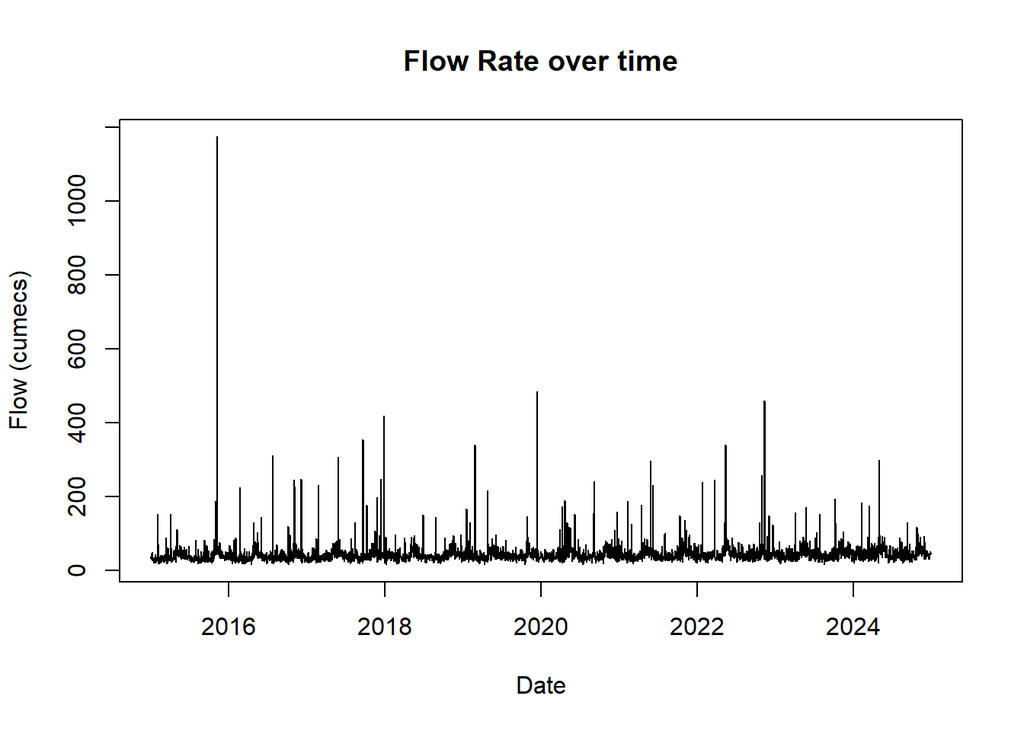

Figure 2: The flow rate over all dates.

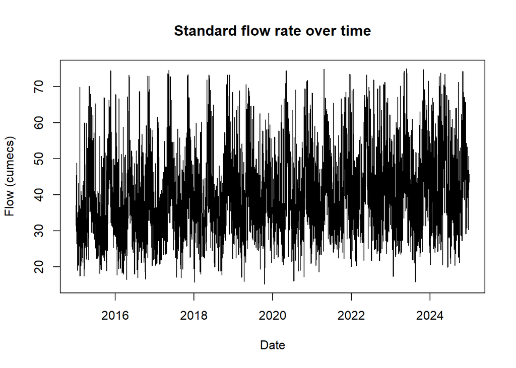

Figure 3: Flow rate excluding extreme situations.

Looking at Figure 2, the trend of flow rate over time is unclear since the data is so skewed by extreme values. To combat this, we can look at Figure 3, which depicts the same information, but without the extreme values. In this case, extreme values are days when flow rate was measured above 75 cumecs.

This graph is much easier to read since all the values are closer together, and appears to demonstrate that whilst there is significant fluctuation, the overall trend is constant when comparing different years.

To get a better understanding, I can then examine the change in baseline mean over time

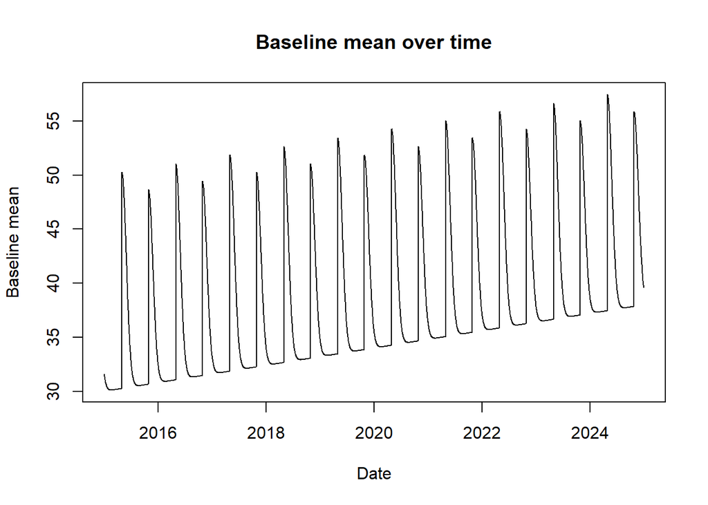

Figure 4: Showing how the baseline mean changes over time.

When considering Figure 4, it is clear that there is actually a significant upwards trend over time, whilst still keeping the same degree of fluctuation during each year.

Lastly, I want to consider the hydrologist’s second claim. To do this, I will examine the extreme measurements against a theoretical GPD distribution.

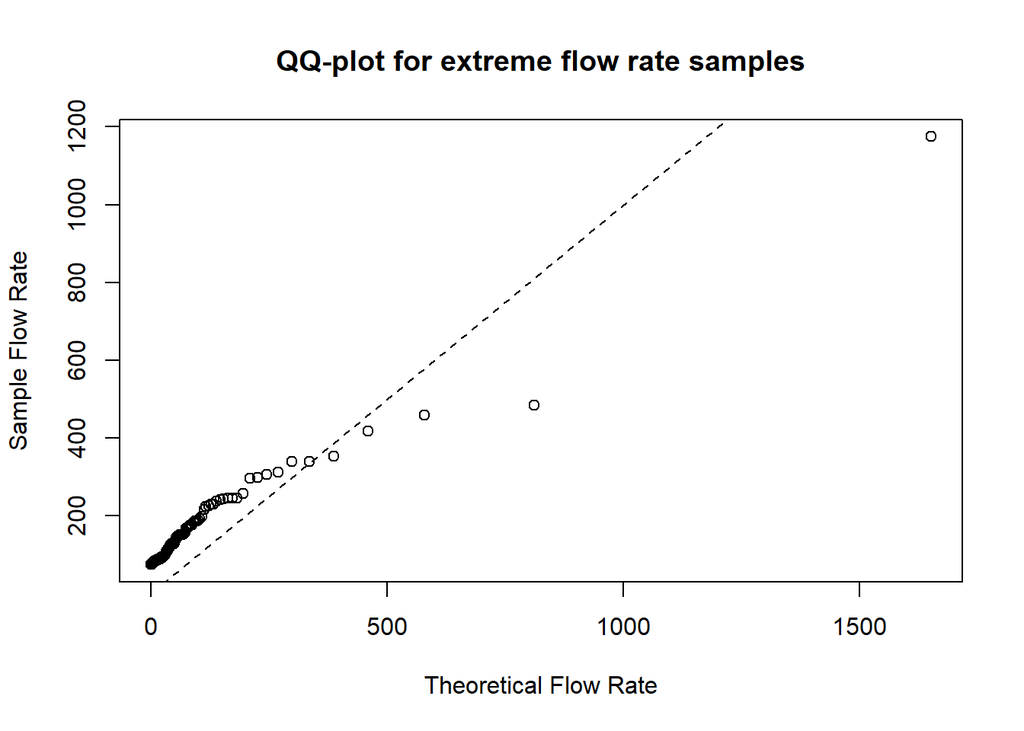

Figure 5: QQ plot comparing the extreme values and the suggested distribution.

From Figure 5, it is clear how the hydrologist came to this conclusion. At lower extreme values, the distribution appears to follow the model relatively well, albeit shifted higher. However, the correlation significantly wavers in the upper quantiles. To conclude, there is not sufficient data to suggest this distribution is completely accurate, although it is a good starting point for a model.

**TipSet yourself up for success**

- Does your document render without any formatting issues?

## Question 5 Reflective Summary

Describe, evidence and reflect on the process of constructing the visualisations in your answer to Question 4.

Your response should be 300-400 words and might, for example, comment on:

- why you chose these forms of visualisation and what alternatives you considered;
- a challenge you faced or something that you learned while making the visualisations;
- how you might approach this task differently with more time or for a different intended audience.

**TipSet yourself up for success**

Does your response:

- describe how you engaged with the visualisation activity;
- give specific evidence of that engagement;
- critically reflection on that engagement?

*End of Assessment.*

### Answer 5

When conducting this investigation, I immediately created Figure 2 to show the flow rate against time, since that was the simpler of the hydrologist’s two proposals. However, I did this without first inspecting the provided data base, and therefore did not realise the difference between the average and extreme values. This meant that the graph was very difficult to acquire any data from, since extreme values were distorting the visualisation. To combat this, I decided to create a separate graph, Figure 3, that ignored the extreme values so that I could see any correlation more easily. This did mean that the extreme values were ignored for this part of the study, but I felt this reasonable since I would consider them later and they were significantly rare to be considered anomalies.

Once I finished this, I realised I needed to use the baseline mean as part of my investigation, however this was easily the most challenging part as it was not clear exactly what this data was portraying. In future, I would want to do more research on this area of the data to understand exactly what to gather from. Nonetheless, I created Figure 4 and was shown a very clear picture of change over time, unlike what I had seen in the original plots.

Lastly, I created Figure 5 to investigate the second of the hydrologist’s claims. This was arguably the simpler part of the investigation, since much of the preparatory work had been done in previous questions. However, I still realised the value of including a line to demonstrate $y=x$, since otherwise any visual reading would be difficult to obtain.

Additionally, I had initially forgotten that I needed to sort the sampled data, or else any comparison to the theoretical values would be meaningless.

In future, I would like to have done more research on the provided data set. If presenting to a less knowledgeable audience, I would also like to explain the meanings of the QQ-plots in more detail.

# Code Appendix

```r
# ANSWER 2
# a)
qgpd <- function(p, u = 0, sigma = 1, xi = 0) {
# Assumes default values if none specified as in qnorm or qunif
# Inputs:
# p: A numeric vector of values in [0, 1]
# u: A location parameter in (-inf, inf)
# sigma: A scale parameter in (0, inf)
# xi: A shape parameter in (-inf, inf)

  for (i in c(p, u, sigma, xi)) {
    if (!is.numeric(i)) {
      stop("All inputs must be numeric.")
    }
  }
  if (any(p < 0 | p > 1)) {
      stop("All probabilities must be in the range [0, 1].")
  }
  if (sigma <= 0) {
    stop("Sigma must be positive.")
  }

  # Calculate quantiles based on the value of xi
  if (xi != 0) {
    return(u + (sigma / xi) * ((1 - p)^(-xi) - 1))
  } else {
    return(u - sigma * log(1 - p))
  }
}
# b)
qgpd(p = c(0.5, 0.75, 0.99), u = 1.5, sigma = 2, xi = -0.4)
# ANSWER 3
# Generate the data frames
gpd_samples <- read.csv("gpd_samples.csv")
gpd_parameters <- read.csv("gpd_parameters.csv")

# Initialise the graph
colours <- c("red", "blue", "darkcyan", "purple", "orange", "brown")
par(mfrow = c(2, 3))
for (i in seq_along(gpd_parameters$id)) {
  id <- gpd_parameters$id[i]
  u <- gpd_parameters$u[i]
  sigma <- gpd_parameters$sigma[i]
  xi <- gpd_parameters$xi[i]
  sample_data <- gpd_samples$value[gpd_samples$set_id == id]
  plot(
    x = qgpd(p = ppoints(length(sample_data)), u = u, sigma = sigma, xi = xi),
    y = sort(sample_data),
    main = paste("Sample", gpd_parameters$id[i]),
    xlab = "Theoretical Quantiles",
    ylab = "Sample Quantiles",
    col = colours[i],
    cex.axis = 1.4,
    cex.lab = 1.4
  )
  abline(a=0, b=1, lty=2) # Understand whether there is a linear relation
}
# Answer 4
river <- read.csv("riverflow_2015_2024.csv")
# Generate flow rate graphs
plot(x=as.Date(river$date),
 y=river$flow,
 xlab = "Date",
 ylab = "Flow (cumecs)",
 type = "l",
 main = "Flow Rate over time")
river_normal <- river[river$flow <= 75, ] # Consider the data frame without the rows with extreme flow rate
plot(x = as.Date(river_normal$date),
y = river_normal$flow,
xlab = "Date",
ylab = "Flow (cumecs)",
type = "l",
main = "Standard flow rate over time")
plot(x = as.Date(river$date),
y = river$baseline_mean,
xlab = "Date",
ylab = "Baseline mean",
type = "l",
main = "Baseline mean over time")
# Generate the QQ plot
river_extreme <- river[river$flow > 75, ] # Restrict the data frame to only the rows with extreme flow rate
plot(x = qgpd(p = ppoints(length(river_extreme$flow)),
 u = 0, sigma = 29.7, xi = 0.62),
 y = sort(river_extreme$flow),
 xlab = "Theoretical Flow Rate",
 ylab = "Sample Flow Rate",
 main = "QQ-plot for extreme flow rate samples")
  abline(a=0, b=1, lty=2) # Test the linearity of the relation
```